# Project 2 - Part 2

### Chandler Ellsworth, Xingwang Yu, Annie Brinza

```python
# Importing libraries
import sqlite3
import pandas as pd
import matplotlib.pyplot as plt

# Setting up connection to database
con = sqlite3.connect("northwind.sqlite")
```

This report is an investigation into the `northwind.sqlite` database for your firm. We are helping you summarize and understand how good your employees are in terms of sales, by drilling down and looking into many aspects of the data, across time and other dimensions. By the end of this report, you will have a good understanding of where the employees stand in terms of sales and can use that knowledge to help improve the overall health of your company.

First, we will look at all of the tables that are available to us for this investigation.

```python
# View all table names
pd.read_sql('SELECT name FROM sqlite_schema WHERE type = "table";', con)
```

|  | name |
| --- | --- |
| 0 | Categories |
| 1 | sqlite_sequence |
| 2 | CustomerCustomerDemo |
| 3 | CustomerDemographics |
| 4 | Customers |
| 5 | Employees |
| 6 | EmployeeTerritories |
| 7 | Order Details |
| 8 | Orders |
| 9 | Products |
| 10 | Regions |
| 11 | Shippers |
| 12 | Suppliers |
| 13 | Territories |

There are many tables that seem to contain relevant information, from what products have been sold, to what regions the products are being sold in. We need to see what kinds of employees you have in order to be able to quantify how well they are doing.

```python
# Query to see titles and count of employees
employees = '''
            SELECT Title, COUNT(Title) AS Total
            FROM Employees
            GROUP BY Title
            ORDER BY COUNT(Title) DESC;
            '''

pd.read_sql(employees,con)
```

|  | Title | Total |
| --- | --- | --- |
| 0 | Sales Representative | 6 |
| 1 | Vice President, Sales | 1 |
| 2 | Sales Manager | 1 |
| 3 | Inside Sales Coordinator | 1 |

There are 9 employees at your firm, including 6 Sales Representatives who will be the main focus of this report.

## Overall Performance

In this section, we will investigate the overall performance of the Sales Representatives.

We would first like to understand the performance of the employees by diving into the sales they have made. In the below table, we have looked at the sales by country, year, and type of product, calculating how much they sold of each grouping. This will be important for diving into the total amount of money each salesperson has made, and it will enable us to investigate if certain sales representatives are better at selling one type of product vs another, as well as if a product does better in one region vs. another.

```python
# Joining together all relevant tables using inner joins

performance_sql ='''
             SELECT e.FirstName || ' ' || e.LastName AS EmployeeName, e.Title, od.OrderID AS OrderNumber, o.CustomerID AS CustomerID, cu.Country, STRFTIME('%Y', Date(o.OrderDate)) AS Year, c.CategoryName, p.ProductName AS Product, od.UnitPrice, od.Quantity, od.Discount,
             ROUND(CAST(od.UnitPrice * od.Quantity * (1 - od.Discount) AS REAL),2) AS SaleTotal
             FROM 'Order Details' as od
             INNER JOIN Orders as o ON o.OrderID = od.OrderID
             INNER JOIN Employees AS e ON e.EmployeeID = o.EmployeeID
             INNER JOIN Products AS p ON p.ProductID = od.ProductID
             INNER JOIN Categories AS c ON c.CategoryID = p.CategoryID
             INNER JOIN Customers AS cu ON cu.CustomerID = o.CustomerID
             ;
             '''

performance = pd.read_sql(performance_sql, con)
performance.head()
```

|  | EmployeeName | Title | OrderNumber | CustomerID | Country | Year | CategoryName | Product | UnitPrice | Quantity | Discount | SaleTotal |
| --- | --- | --- | --- | --- | --- | --- | --- | --- | --- | --- | --- | --- |
| 0 | Steven Buchanan | Sales Manager | 10248 | VINET | France | 1996 | Dairy Products | Queso Cabrales | 14.0 | 12 | 0.0 | 168.0 |
| 1 | Steven Buchanan | Sales Manager | 10248 | VINET | France | 1996 | Grains/Cereals | Singaporean Hokkien Fried Mee | 9.8 | 10 | 0.0 | 98.0 |
| 2 | Steven Buchanan | Sales Manager | 10248 | VINET | France | 1996 | Dairy Products | Mozzarella di Giovanni | 34.8 | 5 | 0.0 | 174.0 |
| 3 | Michael Suyama | Sales Representative | 10249 | TOMSP | Germany | 1996 | Produce | Tofu | 18.6 | 9 | 0.0 | 167.4 |
| 4 | Michael Suyama | Sales Representative | 10249 | TOMSP | Germany | 1996 | Produce | Manjimup Dried Apples | 42.4 | 40 | 0.0 | 1696.0 |

Now that we have retrieved the relevant performance data, we can aggregate it up to the year level to see how the sales employees have performed across the years. In the below table, you can see the total amount of money made by each sales employee over each year. Note that we are including more than just the Sales Representatives in this summary, since we noticed all employees have made some sort of sale.

```python
# Pivoting data to summarize sales totals
totalsales = pd.crosstab(index = performance.Year, columns = performance.EmployeeName, values = performance.SaleTotal, aggfunc = sum)
totalsales
```

| EmployeeName Year | Andrew Fuller | Anne Dodsworth | Janet Leverling | Laura Callahan | Margaret Peacock | Michael Suyama | Nancy Davolio | Robert King | Steven Buchanan |
| --- | --- | --- | --- | --- | --- | --- | --- | --- | --- |
| 1996 | 21757.06 | 9894.52 | 18223.96 | 22240.12 | 49945.12 | 16642.61 | 35764.52 | 15232.16 | 18383.92 |
| 1997 | 70444.14 | 26310.39 | 108026.17 | 56032.63 | 128809.83 | 43126.38 | 93148.13 | 60471.19 | 30716.49 |
| 1998 | 74336.56 | 41103.18 | 76562.75 | 48589.55 | 54135.94 | 14144.16 | 63195.02 | 48864.89 | 19691.90 |

It seems like 1996 was a slower year for most sales representatives, leading into a stronger 1997 and 1998. We will visualize this table into a line graph to better be able to see a trend.

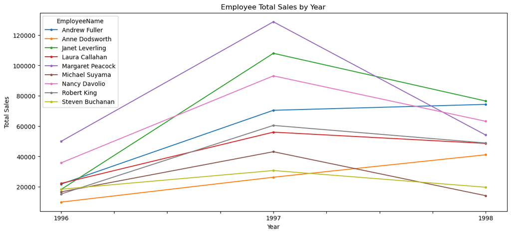

```python
# Creating line graph of sales over year using pivoted data
totalsales.plot.line(figsize = (14,6), style = '.-')
plt.xlabel('Year')
plt.ylabel('Total Sales')
plt.title('Employee Total Sales by Year')
```

The next metric to look into is the average sale size. Diving into this will help you better understand which sales employees are better at larger sales, so when bigger deals come up you will understand who would be a good candidate to put on the deal. We will look at their total orders, total sales, and the average sale size, including the employee title.

```python
# Grouping to get total orders and total sales over all time
averagesale = performance.groupby(['EmployeeName', 'Title']).agg({'OrderNumber' : 'count', 'SaleTotal' : 'sum'})\
                                                 .rename(columns = {'OrderNumber' : 'TotalOrders', 'SaleTotal' : 'TotalSales'})\
                                                 .astype({'TotalOrders' : 'float64'})

# Using total orders and total sales to calculate average sale
averagesale = averagesale.assign(AverageSale = averagesale.TotalSales / averagesale.TotalOrders).round(2).sort_values(by = 'AverageSale', ascending = False)
averagesale
```

| EmployeeName | Title | TotalOrders | TotalSales | AverageSale |
| --- | --- | --- | --- | --- |
| Anne Dodsworth | Sales Representative | 107.0 | 77308.09 | 722.51 |
| Robert King | Sales Representative | 176.0 | 124568.24 | 707.77 |
| Andrew Fuller | Vice President, Sales | 241.0 | 166537.76 | 691.03 |
| Janet Leverling | Sales Representative | 321.0 | 202812.88 | 631.82 |
| Steven Buchanan | Sales Manager | 117.0 | 68792.31 | 587.97 |
| Nancy Davolio | Sales Representative | 345.0 | 192107.67 | 556.83 |
| Margaret Peacock | Sales Representative | 420.0 | 232890.89 | 554.50 |
| Laura Callahan | Inside Sales Coordinator | 260.0 | 126862.30 | 487.93 |
| Michael Suyama | Sales Representative | 168.0 | 73913.15 | 439.96 |

## Category Analysis

Now that we have looked into overall performance, we will dive into looking at performance by category in order to give more specific tips and have a better understanding for why each employee is performing the way they are. We will start with looking into what percentage of our total sales income comes from each category to set the stage up for the rest of the analysis.

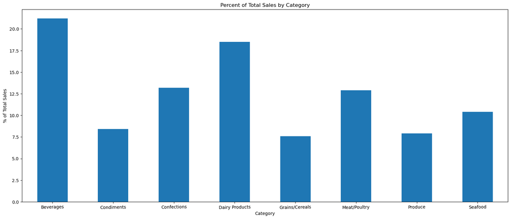

```python
# Querying for category-level results
category_query  = '''
Select c.CategoryName,
STRFTIME('%Y', Date(o.OrderDate)) AS Year,
round(cast(sum(od.UnitPrice * od.Quantity * (1 - od.Discount)) as REAL),2) as TotalSale
from 'Order Details' od
INNER JOIN Orders as o ON o.OrderID = od.OrderID
INNER JOIN Products AS p ON p.ProductID = od.ProductID
INNER JOIN Categories AS c ON c.CategoryID = p.CategoryID
group by CategoryName, Year
'''

category_data = pd.read_sql(category_query, con)

# Getting total sales per category
category_grouped = category_data.groupby('CategoryName').sum(numeric_only = True)

# Calculating percent of total sales
category_grouped['PercentOfTotalSales'] = (category_grouped['TotalSale']/sum(category_grouped['TotalSale'])*100).round(1)

# Plotting bar plot
category_grouped['PercentOfTotalSales'].plot.bar(figsize = (20,8), rot = True)
plt.xlabel('Category')
plt.ylabel('% of Total Sales')
plt.title('Percent of Total Sales by Category')
```

The largest share of sales are from Beverages and Dairy Products, with the smallest being Grains/Cereals and Produce. Understanding this sets the stage for looking at how each employee performs with respect to this distribution. If an employee is over-indexing in Produce, for example, that could make them more valuable since Produce could be a category that there is more sales opportunity for going forward.

We will investigate this next by looking at total percent of sales per employee per category.

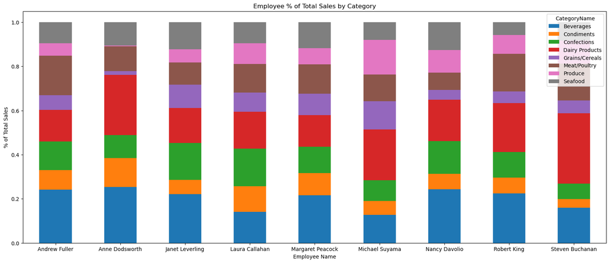

```python
# Getting % of category sales per employee
stacked_category = pd.crosstab(index = performance.CategoryName, columns = performance.EmployeeName, values = performance.SaleTotal, aggfunc = sum, normalize = 'columns')

# Plotting bar plot to show category sales breakdown
stacked_category.transpose().plot.bar(figsize = (20,8), stacked = True, rot = 0)
plt.xlabel('Employee Name')
plt.ylabel('% of Total Sales')
plt.title('Employee % of Total Sales by Category')
```

If you are interested in any further category deep dives, interact with the graph below by choosing a category and year to see how sales were per employee for that year.

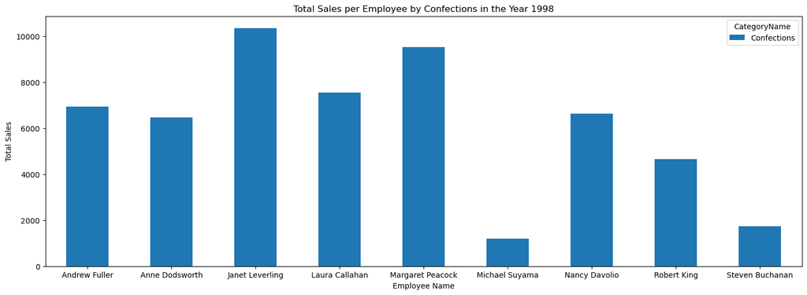

```python
# Creating dynamic graph to dive deeper into employee performance by category
# Choose a category
category_input = input('Category: Dairy Products, Grains/Cereals, Produce, Seafood, Condiments, Confections, Beverages, or Meat/Poultry')
# Choose a year
category_year = input('Year: 1996, 1997, or 1998')

# Filtering data based on user choices
filtered_category_year = performance.loc[(performance['CategoryName'] == str(category_input)) & (performance['Year'] == str(category_year))]
category_bar = pd.crosstab(index = filtered_category_year.EmployeeName, columns = filtered_category_year.CategoryName, values = filtered_category_year.SaleTotal, aggfunc = sum)

# Plotting data
category_bar.plot.bar(figsize = (18,6), rot = 0)
plt.title(f'Total Sales per Employee by {category_input} in the Year {category_year}')
plt.xlabel('Employee Name')
plt.ylabel('Total Sales')
```

## Regional Analysis

Next, we will dive into looking at sales across geographical regions, starting with country. Understanding how each employee performs in each country will give us additional insight into their overall performance. First, we will look at how total sales break down across countries to understand where the majority of our sales go.

```
[Text(0.5, 0, 'Country'), Text(0, 0.5, 'Total Sales')]
```

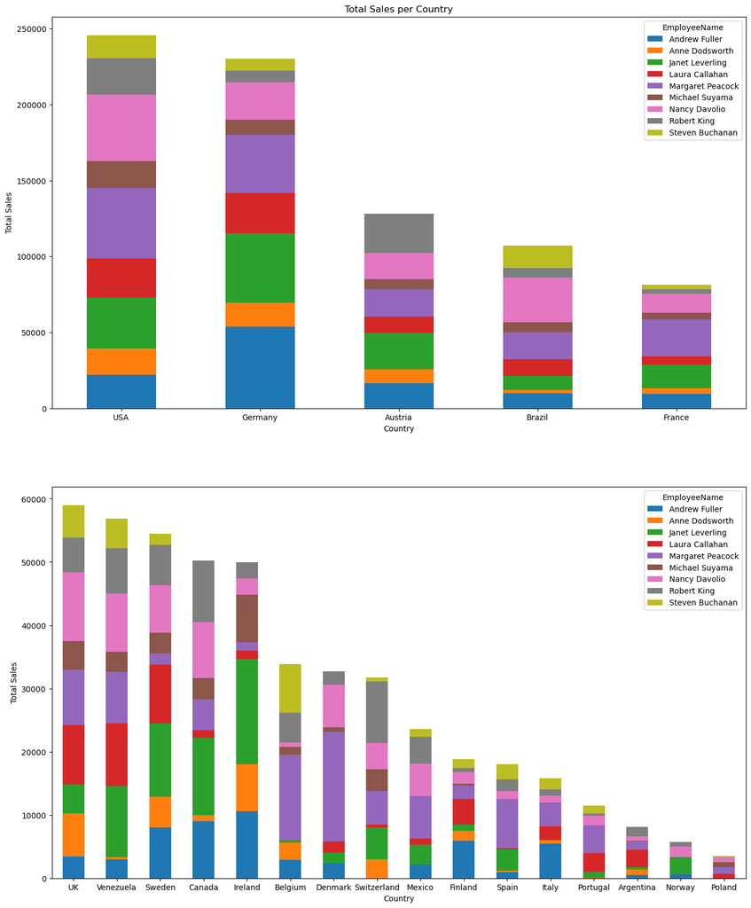

```python
# Need to plot both graphs
fig, (ax1, ax2) = plt.subplots(2,1)

# Getting performance by country
country = pd.crosstab(index = performance.Country, columns = performance.EmployeeName, values = performance.SaleTotal, aggfunc = sum)
stacked_country = country.assign(Total = country.iloc[:,-9:].sum(axis = 1)).sort_values(by= 'Total', ascending = False)
# Visualizing top 5 countries
stacked_country.iloc[0:5,:-1].plot.bar(figsize = (16,20), stacked = True, rot = 0, ax = ax1).set(ylabel = 'Total Sales', title = 'Total Sales per Country')

# Visualizing the rest of the countries
stacked_country.iloc[5:,:-1].plot.bar(figsize = (16,20), stacked = True, rot = 0, ax = ax2).set(xlabel = 'Country', ylabel = 'Total Sales')
```

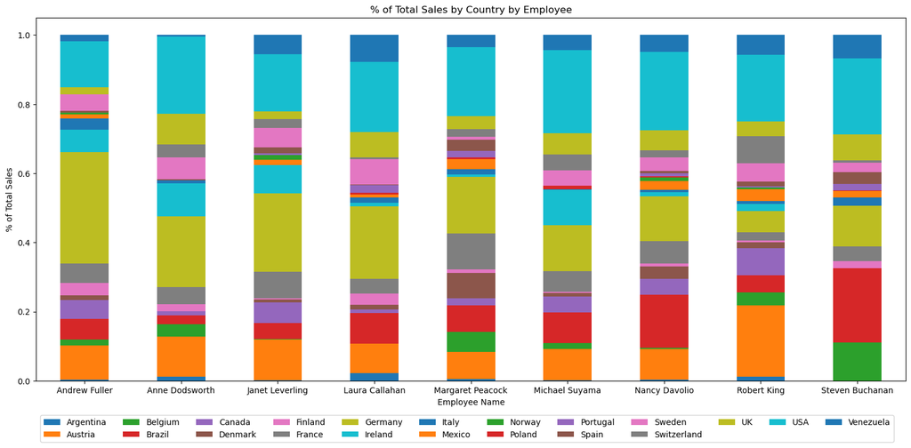

```python
# Calculating % of total sales by country, by employee
country_per = pd.crosstab(index = performance.Country, columns = performance.EmployeeName, values = performance.SaleTotal, aggfunc = sum, normalize = 'columns')

# Plotting figure
country_per.transpose().plot.bar(figsize = (19,8), stacked = True, rot = 0)

# Moving legend to improve readibility
plt.legend(loc='lower left', ncol = 12, bbox_to_anchor=(0, -0.18))
plt.title("% of Total Sales by Country by Employee")
plt.xlabel("Employee Name")
plt.ylabel("% of Total Sales")
```

Now we will look into the breakdown in 1998, since that was the most recent year and the year where several sales employees performances changed.

```
[Text(0.5, 0, 'Country'), Text(0, 0.5, 'Total Sales')]
```

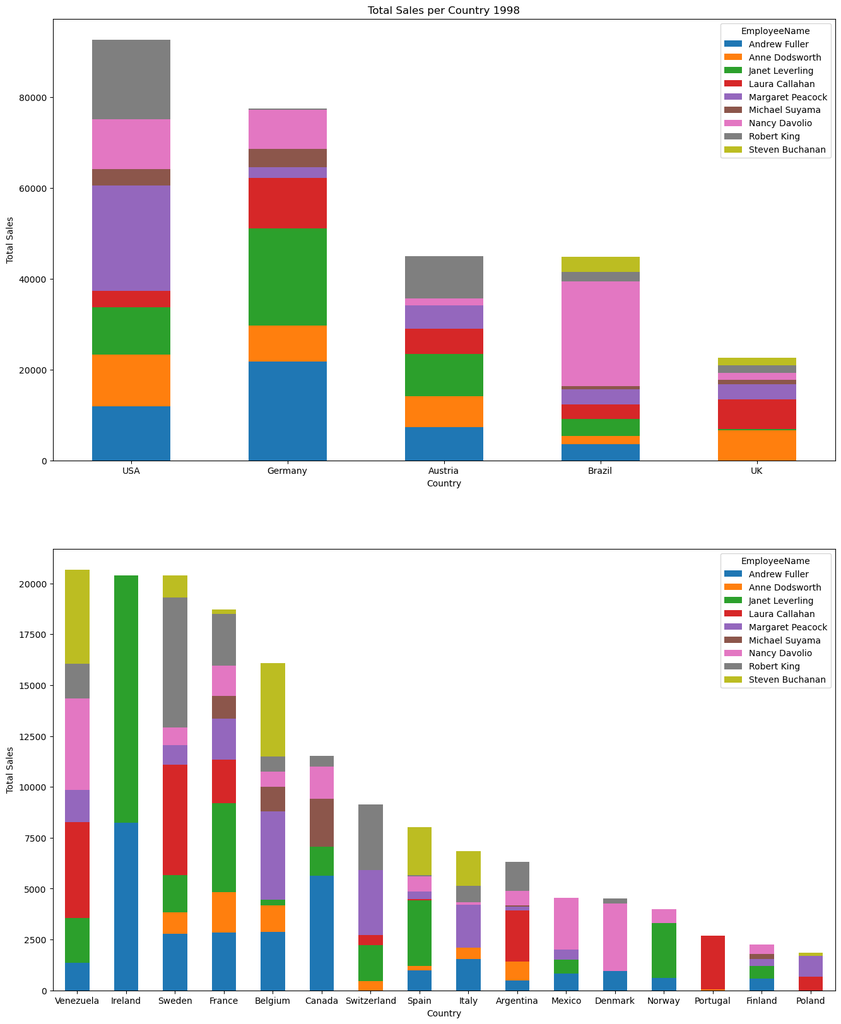

```python
fig, (ax1, ax2) = plt.subplots(2,1)
# Filtering to only have data from 1998
performance_1998 = performance[performance['Year']=='1998']
country = pd.crosstab(index = performance_1998.Country, columns = performance_1998.EmployeeName, values = performance_1998.SaleTotal, aggfunc = sum)
stacked_country = country.assign(Total = country.iloc[:,-9:].sum(axis = 1)).sort_values(by= 'Total', ascending = False)
# Plotting top 5 countries
stacked_country.iloc[0:5,:-1].plot.bar(figsize = (16,20), stacked = True, rot = 0, ax = ax1).set(ylabel = 'Total Sales', title = 'Total Sales per Country 1998')
# Plotting the rest
stacked_country.iloc[5:,:-1].plot.bar(figsize = (16,20), stacked = True, rot = 0, ax = ax2).set(xlabel = 'Country', ylabel = 'Total Sales')
```

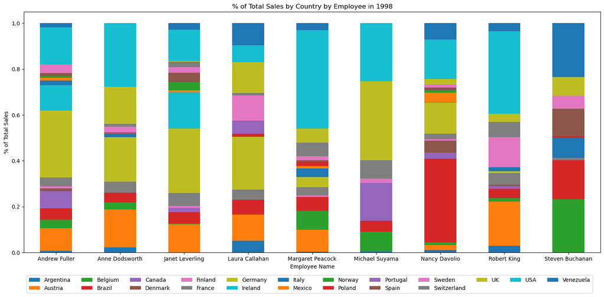

```python
# Calculatign % of total sales for 1998
country_per = pd.crosstab(index = performance_1998.Country, columns = performance_1998.EmployeeName, values = performance_1998.SaleTotal, aggfunc = sum, normalize = 'columns')
# Plotting % of total sales for 1998
country_per.transpose().plot.bar(figsize = (19,8), stacked = True, rot = 0)
plt.legend(loc='lower left', ncol = 12, bbox_to_anchor=(0, -0.18))
plt.title("% of Total Sales by Country by Employee in 1998")
plt.xlabel("Employee Name")
plt.ylabel("% of Total Sales")
```

When looking at Margaret Peacock's shares in aggregate vs 1998 there are a few clear differences that occurred. In 1998, about 40% of her total sales came from the US, and she had no sales in Denmark, Ireland or Canada. Before, she had the lion's share of sales in Denmark, and Denmark was the 12th largest country for sales. In 1998, it plummeted to the 17th largest. This could help explain why Margaret's total sales in 1998 were poorer than the past two years - the market in Denmark shifted, or she didn't have enough time to signficantly invest in that market. Further analysis is recommended before deciding if Margaret needs a performance improvement plan, since it is difficult to ascertain what is responsible for such a drastic change. The other employee with poor performance in 1998 was Michael Suyama, who had the lowest total sales overall. The decrease in his sales seems to be related to a decrease in sales in a few countries - Austria and Ireland mainly, which made up for 20% of his sales in aggregate previously. Again, further analysis is recommended to determine why these markets dropped out of play for Michael, but given their relative positions did not change as much as Denmark's did, it is more likely due to a drop in performance on Michael's part rather than a market shift in the country.

## New Customer Analysis

Another way to look at performance is to see how many new customers an employee brought in, not just total sales. A new customer has many intangibles associated with them, such as increasing brand recognition, creating a pool of new referrals, and more. We'll look at how many new customers were increased by each employee to get that additional metric for performance. We will see how many new customers were signed in 1997 and 1998, compared to the previous year.

```python
# Get new customers developed in 1997 and 1998
customers = performance[["EmployeeName", "OrderNumber", "CustomerID", "Year"]]

df = customers.drop_duplicates('OrderNumber', keep='last')
df_1996 = df.loc[df["Year"] == "1996"]
df_1997 = df.loc[df["Year"] == "1997"]
df_1998 = df.loc[df["Year"] == "1998"]

customerlist_1996 = df_1996["CustomerID"].tolist()
customerlist_1997 = df_1997["CustomerID"].tolist()
customerlist_1998 = df_1998["CustomerID"].tolist()

# Identify which customers were not in the previous year(s)
new_customerslist_1997 = [x for x in customerlist_1997 if x not in customerlist_1996]
new_customerslist_1998 = [x for x in customerlist_1998 if x not in customerlist_1996 and customerlist_1997]

new_customers_1997 = df_1997.loc[df['CustomerID'].isin(new_customerslist_1997)]
new_customers_1998 = df_1998.loc[df['CustomerID'].isin(new_customerslist_1998)]

newcos_count_1997 = new_customers_1997['EmployeeName'].value_counts()
newcos_count_1998 = new_customers_1998['EmployeeName'].value_counts()

# Calculating new customer counts per year
newcos_count = newcos_count_1997.to_frame(name = '1997').join(newcos_count_1998.to_frame(name='1998'))
newcos_count
```

|  | 1997 | 1998 |
| --- | --- | --- |
| Margaret Peacock | 14 | 12 |
| Janet Leverling | 9 | 11 |
| Nancy Davolio | 8 | 5 |
| Laura Callahan | 8 | 3 |
| Andrew Fuller | 8 | 8 |
| Michael Suyama | 7 | 6 |
| Robert King | 4 | 4 |
| Anne Dodsworth | 3 | 4 |
| Steven Buchanan | 2 | 2 |

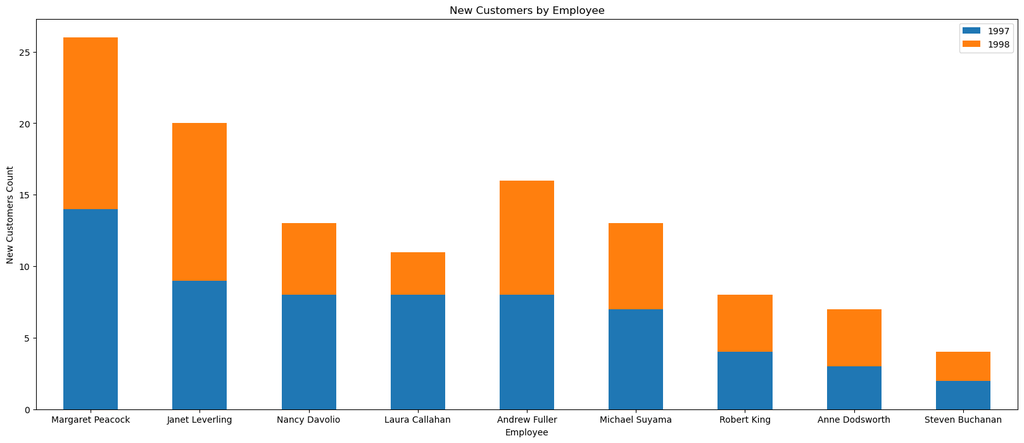

```python
# Plotting new customer counts per employee per year
newcos_count.plot.bar(figsize = (20,8), stacked = True, rot = 0)
plt.xlabel('Employee')
plt.ylabel('New Customers Count')
plt.title('New Customers by Employee')
```

The trend we have been able to see in the previous analyses holds - Margaret Peacock has done the best by far, but she did sign fewer customers in 1998 compared to 1997, reflecting her downward performance trend. However, most employees signed equal to or fewer net new customers in 1998, so this downward trend could just be indicative of a global economic slowing.

It is clear to see that Anne did sign net more customers in 1998 than 1997, signalling her continued performance increases. While her sales numbers are still lower, she seems to be an employee to watch, improving year over year.

Janet Levering is another employee to watch - while her total sales did decrease from 1997 to 1998, she signed more customers in 1998 than 1997, which means she increased the company's intangibles. This is a sign of good performance for an employee, and reinforces that sales numbers are not the only metric to consider.

## Conclusion

Most employees at your company are doing well in terms of sales, even though 1998 was a slower year for the total company revenue. There are a few employees to watch out for - some might need performance management, while others are potential rising stars.

One of the main employees who might need performance management is Michael Suyama. He has had consistenly some of the lower sales numbers, ending 1998 as the lowest performing Sales Representative. On top of that, he signed fewer new customers in 1998 as well. When looking at the countries that Michael makes sales in, his performance seemed to drop more than any other sales employees in those countries, indicating that it was likely a poor performance issue on Michael's end rather than a tumultuous economic situation in those locations.

Maragaret Peacock is another employee who might need performance management - historically, she has been the top Sales Representative, but her performance dropped to the middle of the pack in 1998. She also signed fewer new customers in 1998 as well. Her performance warrants a further investigation, though, since when the countries of her sales were looked at, it seemed like every employee struggled to sell in them in 1998.

On the other hand, Anne Dodsworth seems to be a potential rising star - her sales have increased every year, as well as the new customers she's been signing. This is especially impressive given total company sales decreased in 1998.

We hope that you have found this report informative and useful when trying to understand how good your employees are in terms of sales.